# Island Rule Data Analysis

Load necessary R packages to prepare data for analysis and visualization.

```r
library(googlesheets)
library(tidyr)
library(dplyr)
library(ggplot2)
library(stringr)
```

### **The Data**

Google drive is used to store, share, and access the data. Data are in a google sheet ([CLICK HERE](https://docs.google.com/spreadsheets/d/1mqCaRwuZ0HnMAeVtQ4k-GktEFdChdJiUoweW5PXfZdU/edit?usp=sharing)) with 7 tabs. Data were originally entered by Lauren Nolfo-Clements into a excel spread sheet.

Access the sheet data from Google Drive using the unique google URL key (`gs_key()`) for that sheet. Read data from sheet number 7 (ws =7) and store the values using function `gs_read_csv()` in a R dataframe called `data`.

```r
gs_auth()
```

```
Auto-refreshing stale OAuth token.
```

```r
rd<-gs_url("https://docs.google.com/spreadsheets/d/1mqCaRwuZ0HnMAeVtQ4k-GktEFdChdJiUoweW5PXfZdU/edit#gid=1368341786")
```

```
Sheet-identifying info appears to be a browser URL.
googlesheets will attempt to extract sheet key from the URL.
Putative key: 1mqCaRwuZ0HnMAeVtQ4k-GktEFdChdJiUoweW5PXfZdU
Sheet successfully identified: "Mass Data BOHA 2008-2015"
```

```r
data<-gs_read_csv(rd,ws=7)
```

```
Accessing worksheet titled 'ANOVA'.
```

```
Downloading: 350 B
Downloading: 350 B
Downloading: 530 B
Downloading: 530 B
Downloading: 540 B
Downloading: 540 B
Downloading: 540 B
Downloading: 540 B
```

```
No encoding supplied: defaulting to UTF-8.
```

```r
head(data)
```

| BM08 | BF08 | BM09 | BF09 | BM11 | BF11 | BM14 | BF14 | BM15 | BF15 | PF12 | PM12 | PF14 | PM14 | PF15 | PM15 |
| --- | --- | --- | --- | --- | --- | --- | --- | --- | --- | --- | --- | --- | --- | --- | --- |
| 26.8 | 30.0 | 23.7 | 25.0 | 22.5 | 28.5 | 28.0 | 37.5 | 38 | 32.5 | 24.5 | 31.0 | 28 | 26.0 | 35 | 29.5 |
| 28.0 | 32.0 | 29.5 | 23.0 | 27.0 | 31.3 | 32.0 | 28.3 | 37 | 34.0 | 28.8 | 27.5 | 27 | 28.0 | NA | 37.5 |
| 28.0 | 36.5 | 22.0 | 26.0 | 29.5 | 22.2 | 29.5 | 34.0 | 32 | 31.0 | 28.0 | 37.0 | 30 | 27.0 | NA | 31.5 |
| 30.0 | 30.4 | 24.4 | 29.8 | 26.2 | 23.5 | 34.0 | 29.0 | 33 | 33.0 | 27.0 | 33.0 | 29 | 33.0 | NA | 27.0 |
| 23.0 | 27.5 | 24.5 | 26.5 | 24.5 | 30.0 | 41.0 | 41.0 | 32 | 36.0 | 29.5 | 26.5 | 30 | 31.5 | NA | 29.0 |
| 17.5 | 30.5 | 28.3 | 27.5 | 25.1 | 25.1 | 30.0 | 30.0 | 35 | NA | 29.5 | 33.0 | 30 | 32.0 | NA | 36.0 |

The data from the google sheet are not in a [tidy format](https://www.jstatsoft.org/article/view/v059i10) (i.e., each column is a varaible and each row is an observation). Use `gather()` function to restructure the data.

```r
data<-gather(data,is_sex,mass,na.rm=TRUE)
head(data)
```

| is_sex | mass |
| --- | --- |
| BM08 | 26.8 |
| BM08 | 28.0 |
| BM08 | 28.0 |
| BM08 | 30.0 |
| BM08 | 23.0 |
| BM08 | 17.5 |

Convert body mass values in the `data` dataframe to numeric before plotting and visualization.

```r
data$mass<-as.numeric(data$mass)
head(data)
```

| is_sex | mass |
| --- | --- |
| BM08 | 26.8 |
| BM08 | 28.0 |
| BM08 | 28.0 |
| BM08 | 30.0 |
| BM08 | 23.0 |
| BM08 | 17.5 |

The temporary column `is_sex` contains 3 variables: 1) island sampled, 2) sex of *Peromyscus* captured, and 3) year of sampling. We split `is_sex` and restructure into three new variables (columns of `data`): island, sex, and year. Finally, convert two digit (i.e., 12) years into 4 digit (i.e, 2012) years.

```r
data<-data %>% separate(is_sex,c("sex_is","year"),sep=2)
data<-data %>% separate(sex_is,c("island","sex"),sep=1)
data$year<-as.numeric(str_c(20,data$year))
data
```

|  | island | sex | year | mass |
| --- | --- | --- | --- | --- |
| 1 | B | M | 2008 | 26.80 |
| 2 | B | M | 2008 | 28.00 |
| 3 | B | M | 2008 | 28.00 |
| 4 | B | M | 2008 | 30.00 |
| 5 | B | M | 2008 | 23.00 |
| 6 | B | M | 2008 | 17.50 |
| 7 | B | M | 2008 | 27.00 |
| 8 | B | M | 2008 | 26.50 |
| 9 | B | M | 2008 | 24.50 |
| 10 | B | M | 2008 | 21.00 |

[output cut: 261 more lines]

For plotting purposes, change the codes for island names from B and P to the actual names of each island; Bumpkin and Pedocks.

```r
data$island[data$island=="B"]<-"Bumpkin Island"
data$island[data$island=="P"]<-"Pedocks Island"
head(data)
```

| island | sex | year | mass |
| --- | --- | --- | --- |
| Bumpkin Island | M | 2008 | 26.8 |
| Bumpkin Island | M | 2008 | 28.0 |
| Bumpkin Island | M | 2008 | 28.0 |
| Bumpkin Island | M | 2008 | 30.0 |
| Bumpkin Island | M | 2008 | 23.0 |
| Bumpkin Island | M | 2008 | 17.5 |

**Quick summary of the data**

1. There are more males than females:

```r
table(data$sex)
```

```
  F   M
109 162
```

2. More animals were captured on Bumpkin Island

```r
table(data$island)
```

```
Bumpkin Island Pedocks Island
           187             84
```

3. Most animals were captured in 2009 and 2014; fewer were captured in 2008 and 2012; and 2011 and 2015 had the lowest number of animals captured.

```r
table(data$year)
```

```
2008 2009 2011 2012 2014 2015
  45   77   17   35   71   26
```

Reviewer # 2 stated that “…Island rule is island-dependent, strongly depending on the ecological context on each island” and indicated that “…it is doubtful if the two islands should be pooled.”

Below is a plot of the data over years and by sex. The islands are separate and the relationship between year and mass for each sex (regression) is shown for each island. The parameters and statistics for the regresssion and the assessment of how well the model fits the data are provided below the figure.

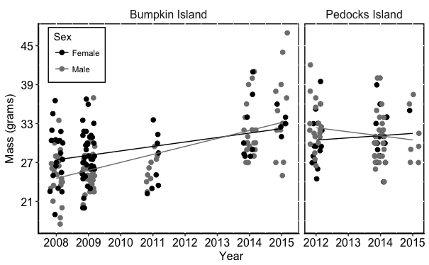

```r
fig3<-ggplot(data) +
    aes(x=year,y=mass,color=sex) +
    geom_point(position=position_jitter(width=0.2),size=2) +
    scale_color_manual(name="Sex",values=c("black","grey50"),labels=c("Female","Male")) +
    geom_smooth(method = "lm",se=F,size=0.5,lty=1)+
    xlab("Year")+
    ylab("Mass (grams)")+
    scale_x_continuous(breaks=seq(2008,2015,1))+
    scale_y_continuous(breaks=seq(15,45,6))+
    theme(axis.title=element_text(face="plain",size=12)) +
    theme(axis.text=element_text(size=12,color ="black"))+
    theme(
        axis.line.x = element_line(colour = 'black', size=0.5, linetype='solid'),
        axis.line.y = element_line(colour = 'black', size=0.5, linetype='solid'))+
    theme(panel.background=element_rect(colour="black",fill="NA",size=1))+
    theme(legend.position=c(0.1,0.85),legend.key=element_rect(fill="NA"))+
    theme(legend.background=element_rect(color="black",size=0.5))+
    theme(strip.background=element_rect(fill="NA"),strip.text.x=element_text(size=12,face="plain"))+
    facet_grid(~island,scales="free_x",space="free_x")
fig3
```

**Save Figure in appropriate format for journal**

```r
ggsave(plot=fig3,filename = "fig3.eps",width=174,height=100,units="mm")
```

### **Statistical analyses**

Analyze (`group_by()`) data separately by `island` and `sex`. Nest (`nest()`) data so that models can be fit and visualized together.

```r
library(broom)
library(modelr)
by_sex_island<- data %>%
    group_by(island,sex) %>%
    nest()
by_sex_island
```

| island | sex | data |
| --- | --- | --- |
| Bumpkin Island | M |  |
| Bumpkin Island | F |  |
| Pedocks Island | F |  |
| Pedocks Island | M |  |

Use `purrr` (R package) and `map` function to fit linear models (regression) to each group (`island` and `sex`) and store model statistics and paramaters as `model` in the `by_sex_island` data frame.

```r
library(purrr)
model<-function(df) {
    lm(mass~year,data=df)
}
by_sex_island<-by_sex_island %>%
    mutate(model=map(data,model))
```

Store the residuals and predictions from the linear model (regression) in the `by_sex_island` dataframe as `resids` and `pred`

```r
by_sex_island<-by_sex_island %>%
    mutate(resids= map2(data,model,add_residuals), pred= map2(data,model,add_predictions))
by_sex_island
```

| island | sex | data | model | resids | pred |
| --- | --- | --- | --- | --- | --- |
| Bumpkin Island | M |  |  |  |  |
| Bumpkin Island | F |  |  |  |  |
| Pedocks Island | F |  |  |  |  |
| Pedocks Island | M |  |  |  |  |

Plot the residuals from the models. First covert the nested dataframe into a regular dataframe using `unnest()` function.

```r
resids<-unnest(by_sex_island,resids)
```

A scatter plot of residuals shows that, overall, the residuals for body mass for each year are mostly equally spaced on either side of zero (white reference line), suggesting that the linear model (regression) has sufficently captured the paterns in the data.

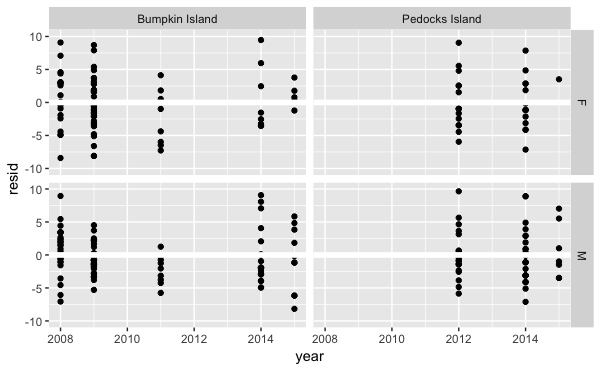

```r
resids %>%
    ggplot(aes(year,resid))+
    geom_point()+
    ylim(-10,10)+
    geom_ref_line(h = 0)+
    facet_grid(sex~island)
```

The density plot of residuals (below) comfirms that the distribution of residuals on either side of zero is approximately equal. Note that in this plot, and the scatter plot above, there are usally larger residual values on the positive side of zero.

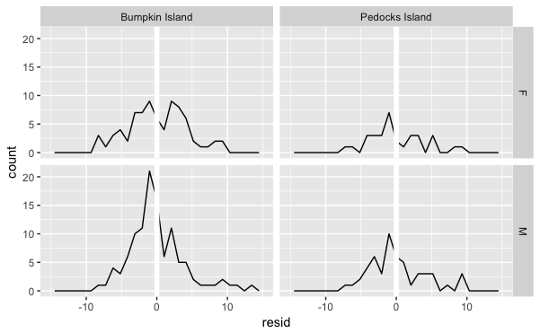

```r
ggplot(resids,aes(resid)) +
    geom_freqpoly()+
    xlim(-15,15)+
    geom_ref_line(v = 0)+
    facet_grid(sex~island)
```

*Below, figures that are identical to the figure shown above to check that the linear regression lines are the same (and they are!)*

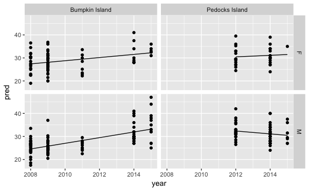

```r
pred<-unnest(by_sex_island,pred)
pred %>%
    ggplot(aes(year,pred))+
    geom_line()+
    geom_point(aes(y=mass))+
    facet_grid(sex~island)
```

Further assess model quality and fit by looking at model parameters (i.e., p-values and r-squared values).

```r
by_sex_island %>%
    mutate(glance=map(model,broom::glance))%>%
    unnest(glance, .drop= TRUE)
```

| island | sex | r.squared | adj.r.squared | sigma | statistic | p.value | df | logLik | AIC | BIC | deviance | df.residual |
| --- | --- | --- | --- | --- | --- | --- | --- | --- | --- | --- | --- | --- |
| Bumpkin Island | M | 0.426136078 | 0.42082252 | 3.845191 | 80.1979260 | 1.096388e-14 | 2 | -303.2246 | 612.4492 | 620.5506 | 1596.8335 | 108 |
| Bumpkin Island | F | 0.120328448 | 0.10859949 | 4.141662 | 10.2590945 | 1.996993e-03 | 2 | -217.6695 | 441.3390 | 448.3705 | 1286.5021 | 75 |
| Pedocks Island | F | 0.008782855 | -0.02425772 | 3.933614 | 0.2658203 | 6.099283e-01 | 2 | -88.1993 | 182.3986 | 186.7958 | 464.1997 | 30 |
| Pedocks Island | M | 0.032642516 | 0.01329537 | 3.909506 | 1.6872003 | 1.999288e-01 | 2 | -143.6624 | 293.3249 | 299.1786 | 764.2117 | 50 |

In general, the fit of the linear models (regressions) for Bumpkin Island are significant. the p-value for males (1.096388e-14) and females (1.996993e-03) are less than 0.05. In addition, the `r.squared` values for males (0.426136078) indicates that the linear model captures over 40% variation in the mass by year. Females have lower values for `r.squared` (0.120328448) but still the linear model captures or explains over 10% of the variation in mass over years.

The latter result is not suprising. Look (below) at the slope and p-valus for the linear models (regressions).

```r
by_sex_island %>%
    mutate(tidy=map(model,broom::tidy))%>%
    unnest(tidy, .drop= TRUE)
```

| island | sex | term | estimate | std.error | statistic | p.value |
| --- | --- | --- | --- | --- | --- | --- |
| Bumpkin Island | M | (Intercept) | -2442.6279861 | 275.8616523 | -8.8545398 | 1.851161e-14 |
| Bumpkin Island | M | year | 1.2286806 | 0.1372010 | 8.9553295 | 1.096388e-14 |
| Bumpkin Island | F | (Intercept) | -1352.3731061 | 431.1837774 | -3.1364193 | 2.443264e-03 |
| Bumpkin Island | F | year | 0.6871454 | 0.2145330 | 3.2029821 | 1.996993e-03 |
| Pedocks Island | F | (Intercept) | -662.0656346 | 1343.9212090 | -0.4926372 | 6.258553e-01 |
| Pedocks Island | F | year | 0.3441944 | 0.6675899 | 0.5155776 | 6.099283e-01 |
| Pedocks Island | M | (Intercept) | 1289.4615721 | 968.4624727 | 1.3314523 | 1.890789e-01 |
| Pedocks Island | M | year | -0.6248035 | 0.4810167 | -1.2989227 | 1.999288e-01 |

The slopes for regressions are positive for both males (1.23) and females (0.69) on Bumpkin Island and both are significant (Male`p.value`= 1.096388e-14; Feamle `p.value`= 1.996993e-03). The slope is greater for males reltative to females providing evidence for a larger increase in body mass over time in males relative to females. This confirms the patterns shown in Figure 3 (see above) and the scatter plot of predictions (see above).

**In general, there is evidence (figure 3), supported by statistical analysis (above), that the body mass of male and female mice on Bumpkin Island have increased over time.**  
**THIS GOES IN THE PAPER**

### **Hypothesis Testing**

Given the evidence for a increase in body mass on Bumpkin Island over time, it is, perhaps, necessary to test the hypothesis that body masses are significanly larger later in the sampling period.

First test for differences in mean mass between sexes and years and interactions between sex and year using `anova`.

```r
by_island<-data %>%
    group_by(island) %>%
    nest()
model2<-function(df){
    lm(mass~sex*year,data=df)
}
by_island<-by_island%>%
    mutate(model=map(data,model2)) %>%
    mutate(anova=map(model,anova))
by_island<-by_island %>%
    mutate(tidy= map(anova,tidy)) %>%
    unnest(tidy, .drop=TRUE)
by_island
```

| island | term | df | sumsq | meansq | statistic | p.value |
| --- | --- | --- | --- | --- | --- | --- |
| Bumpkin Island | sex | 1 | 36.540150 | 36.540150 | 2.3191360 | 1.295171e-01 |
| Bumpkin Island | year | 1 | 1287.618447 | 1287.618447 | 81.7227715 | 2.234127e-16 |
| Bumpkin Island | sex:year | 1 | 74.125596 | 74.125596 | 4.7046151 | 3.137162e-02 |
| Bumpkin Island | Residuals | 183 | 2883.335593 | 15.755932 | NA | NA |
| Pedocks Island | sex | 1 | 8.994884 | 8.994884 | 0.5857897 | 4.463040e-01 |
| Pedocks Island | year | 1 | 8.532181 | 8.532181 | 0.5556563 | 4.582003e-01 |
| Pedocks Island | sex:year | 1 | 21.368505 | 21.368505 | 1.3916189 | 2.416281e-01 |
| Pedocks Island | Residuals | 80 | 1228.411345 | 15.355142 | NA | NA |

The results of `anova`(above) confirm the results from model (regression) analysis. There is no significant difference in mean body mass between sexes on Pedocks Island (p=0.446304) or between years (p=0.4582003). The interaction between year and sex is also not significant (p=0.2416281).

Follow up with a pariwise test to look more closely at the differences in mass over years.

```r
data_bump<-data %>%
    filter(island=="Bumpkin Island")
bump_mass<-tidy(pairwise.t.test(data_bump$mass,data_bump$year,p.adjust.method = "bonferroni"))
bump_mass
```

|  | group1 | group2 | p.value |
| --- | --- | --- | --- |
| 1 | 2009 | 2008 | 1.000000e+00 |
| 2 | 2011 | 2008 | 1.000000e+00 |
| 3 | 2014 | 2008 | 2.154501e-06 |
| 4 | 2015 | 2008 | 1.217873e-09 |
| 6 | 2011 | 2009 | 1.000000e+00 |
| 7 | 2014 | 2009 | 5.078261e-07 |
| 8 | 2015 | 2009 | 2.721711e-10 |
| 11 | 2014 | 2011 | 4.772598e-04 |
| 12 | 2015 | 2011 | 7.192269e-07 |
| 16 | 2015 | 2014 | 3.463030e-01 |

Construct an interactoon plot to visualize any potential interactions between body mass, sex and years. Plot the mean mass for males and females each year and look for interactions. Basically, over time is the avreage mass of males and females responding/changing in the same way (see below).

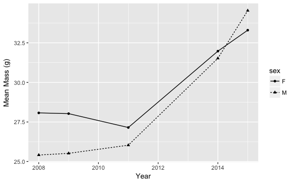

```r
data_bump %>%
    group_by(sex,year) %>%
    summarise(mass=mean(mass)) %>%
    ggplot(aes(year,mass,group=sex)) +
    geom_point(aes(shape=sex)) +
    geom_line(aes(linetype=sex)) +
    ylab("Mean Mass (g)") +
    xlab("Year")
```

As suggested by the ANOVA (above) and shown in this plot, the mean mass of mice differ considerably between early (2008, 2009, and 2011) and later years (2014-2015). There is a large (significant, from `anova` above) increase in average mass between 2011 and 2014.

Fit linear models to each year separately and look at estimates of mean body mass for both sexes. Should help to understand where male and female mean masses are, perahps, different and, perhaps, changing over years in different ways.

```r
data_bump_by_year<-data_bump %>%
    group_by(year) %>%
    nest()
model3 <-function(df) {
    lm(mass~sex,data=df)
}
data_bump_by_year %>%
    mutate(model=map(data,model3)) %>%
    mutate(tidy=map(model,tidy)) %>%
    unnest(tidy,.drop=TRUE)
```

| year | term | estimate | std.error | statistic | p.value |
| --- | --- | --- | --- | --- | --- |
| 2008 | (Intercept) | 28.0736842 | 0.9066215 | 30.9651653 | 4.945027e-31 |
| 2008 | sexM | -2.6621457 | 1.1927395 | -2.2319591 | 3.088033e-02 |
| 2009 | (Intercept) | 28.0270270 | 0.5545717 | 50.5381454 | 1.099224e-59 |
| 2009 | sexM | -2.5095270 | 0.7694371 | -3.2615105 | 1.668824e-03 |
| 2011 | (Intercept) | 27.1500000 | 1.1791946 | 23.0241888 | 4.064752e-13 |
| 2011 | sexM | -1.1166667 | 1.6206480 | -0.6890248 | 5.013274e-01 |
| 2014 | (Intercept) | 31.9750000 | 1.5224124 | 21.0028508 | 1.119886e-18 |
| 2014 | sexM | -0.4522727 | 1.7777946 | -0.2544010 | 8.010449e-01 |
| 2015 | (Intercept) | 33.3000000 | 2.5471326 | 13.0735242 | 5.889330e-10 |
| 2015 | sexM | 1.2384615 | 2.9972028 | 0.4132058 | 6.849407e-01 |

```r
NA
```

**Whether any of the latter is significant and worth considering is questionable given the potential for non-independence between years and multiple comparisons over years with no adjustment of p.values.**